# Sentiment Analysis

Ramiro Casó - Incae Business School

3/30/2021

## Diccionarios de sentimientos

Para hacer análisis de sentimiento, se recomiendo utilizar diccionarios de sentimientos existentes. El paquete `tidytext` trae varios diccionarios pre-cargados, pero están todos en inglés.

- Bing dictionario: un data frame con palabras categorizadas por sentimientos positivo o negativo

```r
library(tidytext)
library(textdata)
get_sentiments("bing")
```

```
## # A tibble: 6,786 x 2
##    word        sentiment
##    <chr>       <chr>
##  1 2-faces     negative
##  2 abnormal    negative
##  3 abolish     negative
##  4 abominable  negative
##  5 abominably  negative
##  6 abominate   negative
##  7 abomination negative
##  8 abort       negative
##  9 aborted     negative
## 10 aborts      negative
## # … with 6,776 more rows
```

```r
get_sentiments("bing") %>%
  count(sentiment)
```

```
## # A tibble: 2 x 2
##   sentiment     n
##   <chr>     <int>
## 1 negative   4781
## 2 positive   2005
```

- Afinn dictionary: un data frame con palabras a las que se les asigna un puntaje numérico de sentimiento.

```r
get_sentiments("afinn")
```

```
## # A tibble: 2,477 x 2
##    word       value
##    <chr>      <dbl>
##  1 abandon       -2
##  2 abandoned     -2
##  3 abandons      -2
##  4 abducted      -2
##  5 abduction     -2
##  6 abductions    -2
##  7 abhor         -3
##  8 abhorred      -3
##  9 abhorrent     -3
## 10 abhors        -3
## # … with 2,467 more rows
```

```r
get_sentiments("afinn") %>%
  summarize(
    min = min(value),
    max = max(value)
  )
```

```
## # A tibble: 1 x 2
##     min   max
##   <dbl> <dbl>
## 1    -5     5
```

- Loughran dictionary: un data frame con palabras a las que se les asigna una categoría nominal de sentimiento a cada palabra. A diferencia de `bing` este diccionario usa distintas categorías, no solo positivo y negativo.

Para echarle un ojo a este diccionario, podemos usar el siguiente código.

```r
get_sentiments("loughran")
```

```
## # A tibble: 4,150 x 2
##    word         sentiment
##    <chr>        <chr>
##  1 abandon      negative
##  2 abandoned    negative
##  3 abandoning   negative
##  4 abandonment  negative
##  5 abandonments negative
##  6 abandons     negative
##  7 abdicated    negative
##  8 abdicates    negative
##  9 abdicating   negative
## 10 abdication   negative
## # … with 4,140 more rows
```

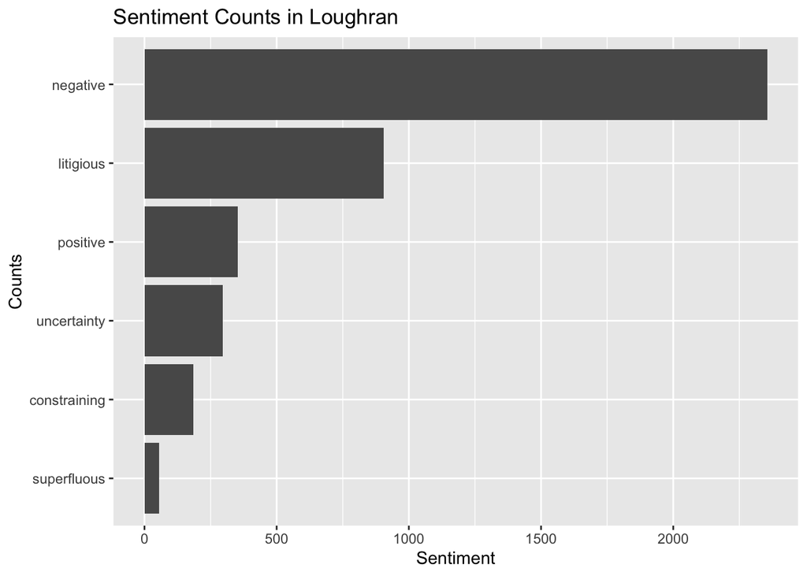

```r
sentiment_counts <- get_sentiments("loughran") %>%
  count(sentiment) %>%
  mutate(sentiment2 = fct_reorder(sentiment,n))

ggplot(sentiment_counts, aes(x=sentiment2, y=n)) +
  geom_col() +
  coord_flip() +
  labs(
    title = "Sentiment Counts in Loughran",
    x = "Counts",
    y = "Sentiment"
  )
```

- NRC dictionary: Por último, el diccionario NRC, que es quizá el más completo. Categoriza las palabras en función de 10 tipos de sentimientos, como se puede ver en el resumen que hacemos seguidamente.

```r
get_sentiments("nrc")
```

```
## # A tibble: 13,901 x 2
##    word        sentiment
##    <chr>       <chr>
##  1 abacus      trust
##  2 abandon     fear
##  3 abandon     negative
##  4 abandon     sadness
##  5 abandoned   anger
##  6 abandoned   fear
##  7 abandoned   negative
##  8 abandoned   sadness
##  9 abandonment anger
## 10 abandonment fear
## # … with 13,891 more rows
```

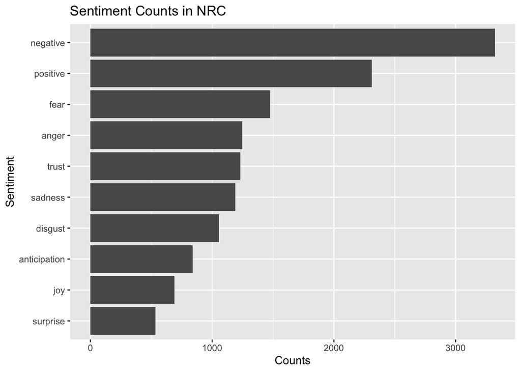

```r
sentiment_counts <- get_sentiments("nrc") %>%
  count(sentiment) %>%
  mutate(sentiment2 = fct_reorder(sentiment,n))

ggplot(sentiment_counts, aes(sentiment2, y=n)) +
  geom_col() +
  coord_flip() +
    labs(
    title =  "Sentiment Counts in NRC",
    x = "Sentiment",
    y = "Counts"
  )
```

## Añadiendo los diccionarios de sentimientos

Ahora que tenemos los diccionarios, debemos añadirlos a nuestro data frame de palabras ya limpios.

```r
# Nuestro data frame original
review_data <- read_csv("Roomba Reviews.csv")
# Estas eras nuestras stopwords custom.
word <- c("roomba","2")
lexicon <- c("CUSTOM", "CUSTOM")
custom_sw <-data.frame(word,lexicon)

# Así las uníamos al df de stopwords que trae el paquete tidytext
stop_words2 <- stop_words %>%
  bind_rows(custom_sw)

# Así creamos el objeto tidy_review en el que ya tenemos limpia toda la data, tokenizada y libre de stopwords.
tidy_review <- review_data %>%
  mutate(id= row_number()) %>%
  select(id, Date, Product, Stars, Review) %>%
  unnest_tokens(word, Review) %>%
  anti_join (stop_words2)
#finalmente, unimos el diccionario a data frame tidy_review

tidy_review %>%
  inner_join(get_sentiments("loughran"))
```

```
## # A tibble: 3,960 x 6
##       id Date     Product                    Stars word      sentiment
##    <int> <chr>    <chr>                      <dbl> <chr>     <chr>
##  1     5 12/22/15 iRobot Roomba 650 for Pets     5 slow      negative
##  2     5 12/22/15 iRobot Roomba 650 for Pets     5 easily    positive
##  3     5 12/22/15 iRobot Roomba 650 for Pets     5 random    uncertainty
##  4     5 12/22/15 iRobot Roomba 650 for Pets     5 easy      positive
##  5     5 12/22/15 iRobot Roomba 650 for Pets     5 easy      positive
##  6     5 12/22/15 iRobot Roomba 650 for Pets     5 easy      positive
##  7     6 12/27/15 iRobot Roomba 650 for Pets     5 invention positive
##  8     7 8/17/15  iRobot Roomba 650 for Pets     1 damage    negative
##  9     7 8/17/15  iRobot Roomba 650 for Pets     1 damage    negative
## 10     7 8/17/15  iRobot Roomba 650 for Pets     1 justice   litigious
## # … with 3,950 more rows
```

Noten que usamos un inner join. Eso lo que hace es unir dos tables a través de la columna word, siempre y cuando coincidan las dos palabras. De este modo, dejamos en nuestro data frame solo aquellos sentimientos de las palabras que tokenizamos.

## Contando sentimientos

Una vez que hemos añadido el diccionario, podemos hacer análisis de los sentimientos más comunes en nuestro data set.

Veamos cómo

```r
# creamos un objeto llamado sentiment_review en donde guardaremos la unión del diccionario con nuestro df.
sentiment_review <- tidy_review %>%
  inner_join(get_sentiments("loughran"))
str(sentiment_review)
```

```
## tibble [3,960 × 6] (S3: tbl_df/tbl/data.frame)
##  $ id       : int [1:3960] 5 5 5 5 5 5 6 7 7 7 ...
##  $ Date     : chr [1:3960] "12/22/15" "12/22/15" "12/22/15" "12/22/15" ...
##  $ Product  : chr [1:3960] "iRobot Roomba 650 for Pets" "iRobot Roomba 650 for Pets" "iRobot Roomba 650 for Pets" "iRobot Roomba 650 for Pets" ...
##  $ Stars    : num [1:3960] 5 5 5 5 5 5 5 1 1 1 ...
##  $ word     : chr [1:3960] "slow" "easily" "random" "easy" ...
##  $ sentiment: chr [1:3960] "negative" "positive" "uncertainty" "positive" ...
```

```r
# Ahora podemos empezar a hacer análisis, como contar, por ejemplo.

sentiment_review %>%
  count(sentiment) %>%
  arrange(desc(n))
```

```
## # A tibble: 6 x 2
##   sentiment        n
##   <chr>        <int>
## 1 negative      1795
## 2 positive      1568
## 3 uncertainty    373
## 4 constraining   170
## 5 litigious       53
## 6 superfluous      1
```

Otra cosa que podemos hacer es contar por palabra y por sentimiento

```r
sentiment_review %>%
  count(word, sentiment) %>%
  arrange(desc(n))
```

```
## # A tibble: 598 x 3
##    word      sentiment       n
##    <chr>     <chr>       <int>
##  1 easy      positive      297
##  2 happy     positive      107
##  3 easier    positive       97
##  4 easily    positive       92
##  5 perfect   positive       87
##  6 random    uncertainty    81
##  7 impressed positive       77
##  8 excellent positive       58
##  9 trouble   negative       58
## 10 fantastic positive       56
## # … with 588 more rows
```

## Visualizando sentimientos

Utilizando mucho de lo aprendido en este turorial de Text Mining, podemos ahora visualizar los sentimientos.

```r
# creamos el objeto sentiment_review2 en el que solo dejamos las filas que contengan sentimientos positivos o negativos.

sentiment_review2 <- sentiment_review %>%
  filter(sentiment %in% c("positive", "negative"))

# rehacemos el objetio word_counts.

word_counts <-sentiment_review2 %>%
  count(word,sentiment) %>%
  group_by(sentiment) %>%
  top_n(10,n) %>%
  ungroup() %>%
  mutate(
    word2 = fct_reorder(word,n)
  )
word_counts
```

```
## # A tibble: 20 x 4
##    word         sentiment     n word2
##    <chr>        <chr>     <int> <fct>
##  1 bad          negative     47 bad
##  2 damage       negative     32 damage
##  3 disappointed negative     42 disappointed
##  4 easier       positive     97 easier
##  5 easily       positive     92 easily
##  6 easy         positive    297 easy
##  7 error        negative     37 error
##  8 excellent    positive     58 excellent
##  9 fantastic    positive     56 fantastic
## 10 happy        positive    107 happy
## 11 impressed    positive     77 impressed
## 12 improvement  positive     35 improvement
## 13 lost         negative     41 lost
## 14 miss         negative     35 miss
## 15 missed       negative     33 missed
## 16 perfect      positive     87 perfect
## 17 pleased      positive     37 pleased
## 18 stopped      negative     53 stopped
## 19 stops        negative     37 stops
## 20 trouble      negative     58 trouble
```

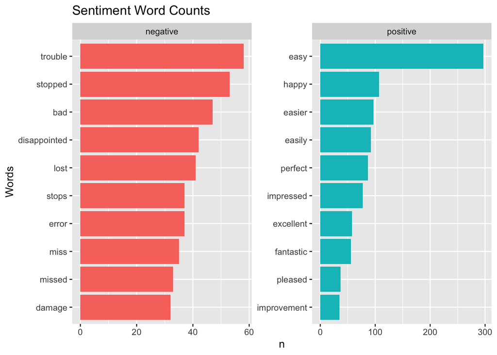

```r
# Hacemos el gráfico de barras
ggplot(word_counts, aes(x=word2, y=n, fill = sentiment)) +
  geom_col(show.legend = FALSE) +
  facet_wrap(~ sentiment, scales = "free") +
  coord_flip() +
  labs(
    title = "Sentiment Word Counts",
    x = "Words"
  )
```

## Incluyendo los ratings.

Ya hemos visualizado bien los sentimientos. ¿Qué más podemos hacer? Podemos utilizar la información numérica en los ratings para hacer más completo el análisis.

Para ello, debemos usar la función `spread` que nos permite pasar los valores de una variable categórica (en este caso los sentimientos) a columnas y llenarlos con el conteo o n.

Vemoa

```r
tidy_review %>%
  inner_join(get_sentiments("bing")) %>%
  count(Stars, sentiment) %>%
  spread(sentiment, n) # Noten que acá spread lo que hace es poner los sentimientos separados (es decir, spreded) en columnas y lo llena con el conteno.
```

```
## # A tibble: 5 x 3
##   Stars negative positive
##   <dbl>    <int>    <int>
## 1     1      381      241
## 2     2      384      247
## 3     3      485      432
## 4     4      984      973
## 5     5     3705     5083
```

Con este nuevo arreglo, podemos hacer un cálculo de la diferencia entre positivos y negativos, e incluso el % relativo del total. Solo debemos usar la función `mutate` para ello.

Veamos.

```r
tidy_review %>%
  inner_join(get_sentiments("bing")) %>%
  count(Stars, sentiment) %>%
  spread(sentiment, n) %>%
  mutate(overall_sentiment = positive - negative, pos_relative = (positive / (positive + negative))*100, neg_relative = (negative /(positive + negative))*100)
```

```
## # A tibble: 5 x 6
##   Stars negative positive overall_sentiment pos_relative neg_relative
##   <dbl>    <int>    <int>             <int>        <dbl>        <dbl>
## 1     1      381      241              -140         38.7         61.3
## 2     2      384      247              -137         39.1         60.9
## 3     3      485      432               -53         47.1         52.9
## 4     4      984      973               -11         49.7         50.3
## 5     5     3705     5083              1378         57.8         42.2
```

Reordenmos lo hecho anterioremente y en una versión más simple, para visualizarlo.

```r
sentiment_stars <- tidy_review %>%
  inner_join(get_sentiments("bing")) %>%
  count(Stars, sentiment) %>%
  spread(sentiment, n) %>%
  mutate(overall_sentiment = positive - negative,
         stars2 = fct_reorder(as.factor(Stars), overall_sentiment
                             ))
```

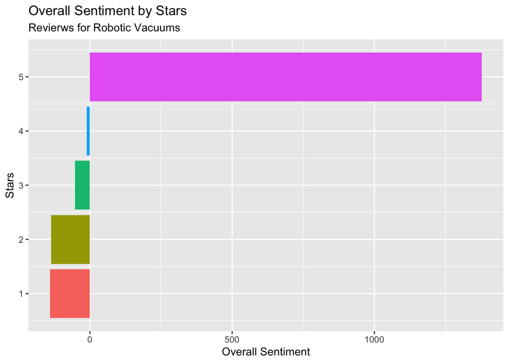

```r
ggplot(sentiment_stars,
       aes(x=Stars, y=overall_sentiment, fill = as.factor(Stars))
       ) +
  geom_col(show.legend = FALSE) +
  coord_flip() +
  labs(
    title = "Overall Sentiment by Stars",
    subtitle = "Revierws for Robotic Vacuums",
    legend.title = "Stars Ratings",
    x = "Stars",
    y = "Overall Sentiment"
  )
```

Si quisiéramos, podríamos también visualizar los valores relativos que hicimos anteriormente.

Veamos

```r
sentiment_stars_rel <-tidy_review %>%
  inner_join(get_sentiments("bing")) %>%
  count(Stars, sentiment) %>%
  spread(sentiment, n) %>%
  mutate(overall_sentiment = positive - negative, pos_relative = (positive / (positive + negative))*100, neg_relative = (negative /(positive + negative))*100)
```

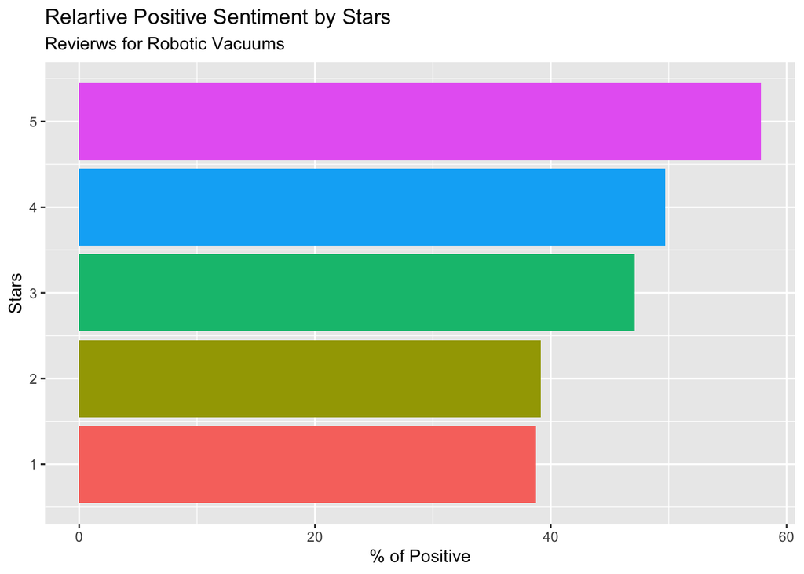

```r
ggplot(sentiment_stars_rel,
       aes(x=Stars, y=pos_relative, fill = as.factor(Stars))
       ) +
  geom_col(show.legend = FALSE) +
  coord_flip() +
  labs(
    title = "Relartive Positive Sentiment by Stars",
    subtitle = "Revierws for Robotic Vacuums",
    x = "Stars",
    y = "% of Positive"
  )
```

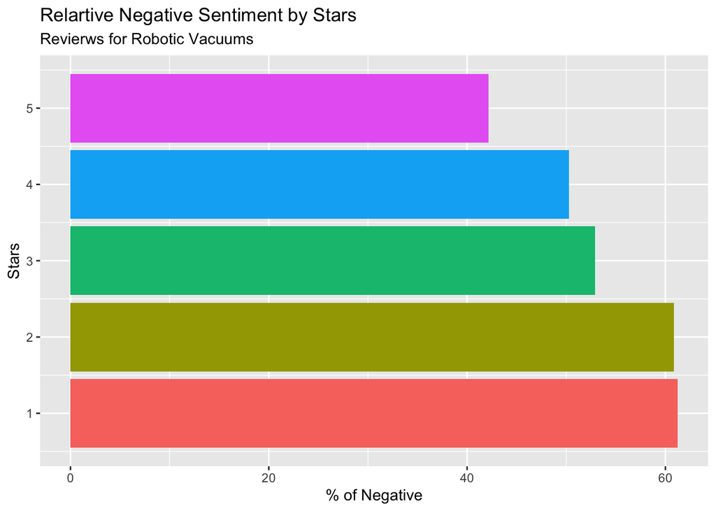

```r
ggplot(sentiment_stars_rel,
       aes(x=Stars, y=neg_relative, fill = as.factor(Stars))
       ) +
  geom_col(show.legend = FALSE) +
  coord_flip() +
  labs(
    title = "Relartive Negative Sentiment by Stars",
    subtitle = "Revierws for Robotic Vacuums",
    x = "Stars",
    y = "% of Negative"
  )
```